# Tutorial of sraster

DGT Portugal, William Martinez

05/08/2019

# 1 Introduction

The attempt of this tutorial is to document the implmentation of the cluster analysis developed in Pari’s paper.

```r
source('C:\\IPSTERS\\sraster\\R\\clip_raster.R')

#===============================
#Example
#===============================

library(rgdal)
library(sf)
library(stars)
library(raster)

file_shape = 'C:\\IPSTERS\\COS2015\\COS2015_v2_08_02_2019_clip.shp'
legend = st_read(file_shape)
```

```r
legend_water = legend[which(legend$Legend == 'water'),]

#===============================
#Calling imagery
#===============================

images_folder = 'C:\\IPSTERS\\IMAGES'
#images_folder = '/home/willimarti2008/Documents/DGT/images'
join_path = function(x,path_folder){
  a = strsplit(x,'[.]')
  format_file = a[[1]][length(a[[1]])]
  if(format_file == 'tif'){
    return(paste0(path_folder,'/',x))
  }
}

list_images1 = list.files(images_folder)
list_images2 = c("S2A_L2A_20171002-113001_T29SND.tif",
                 "S2A_L2A_20171121-112837_T29SND.tif",
                 "S2A_L2A_20171221-112810_T29SND.tif",
                 "S2A_L2A_20180321-112321_T29SND.tif",
                 "S2A_L2A_20180619-112602_T29SND.tif",
                 "S2A_L2A_20180729-112845_T29SND.tif",
                 "S2A_L2A_20180818-112627_T29SND.tif",
                 "S2A_L2A_20180927-112959_T29SND.tif",
                 "S2A_L2A_20181007-112305_T29SND.tif")

paths_images = unlist(lapply(list_images2,join_path,images_folder))
```

# 2 Example Polygon Obj 92266

## 2.1 sraster object

For the 92266 polygon we want to extract the spectral and temporal information associated to Snetinel 2 2018. The function as_raster also provides NDVI index. Since we have 9 images with 10 bands of sentinel 2, plus NDVI per image, in total we have 99 layers for our cluster analysis.

```r
shape = legend_water[legend_water$OBJECTID == 92266,]
result = as_sraster(shape,paths_images)
```

```
##  Shape 92266
##
```

```r
result
```

```
## class:    sraster
## space dimension: nrows:  21  nccols:  23
## Number of layers:  99
## Number of images:  9
## Coord Origin x:  585325  and y:  4362685
```

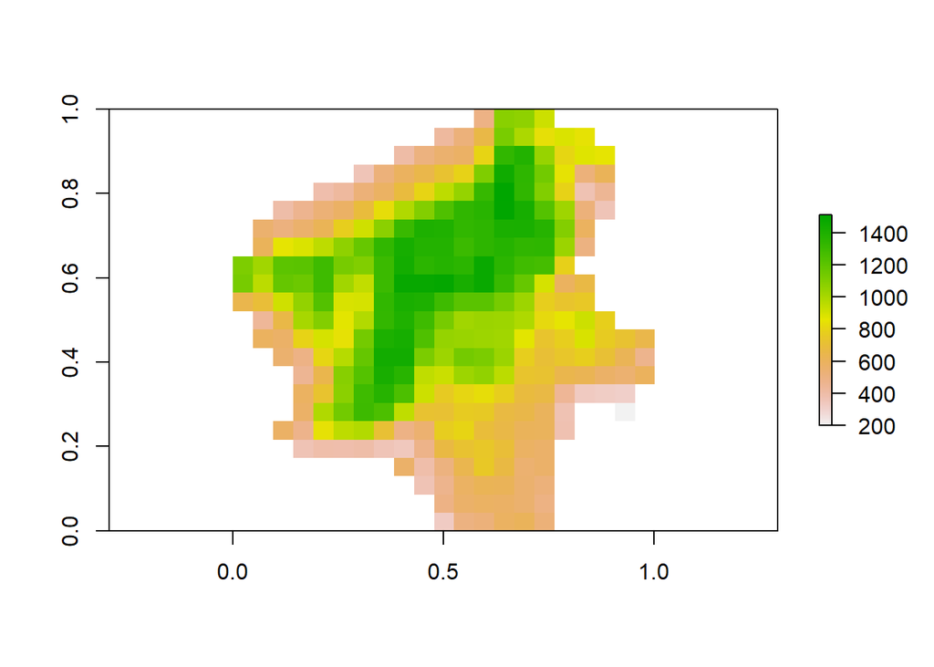

```r
plot(funct_plot((result$array)[,,1]))
```

## 2.2 K means

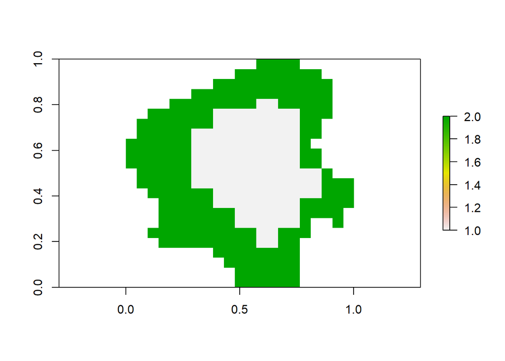

```r
cluster_matrix = kmeans_sraster(result)
plot(funct_plot(cluster_matrix))
```

### 2.2.1 Extracting spectral temporal information with Majority rule

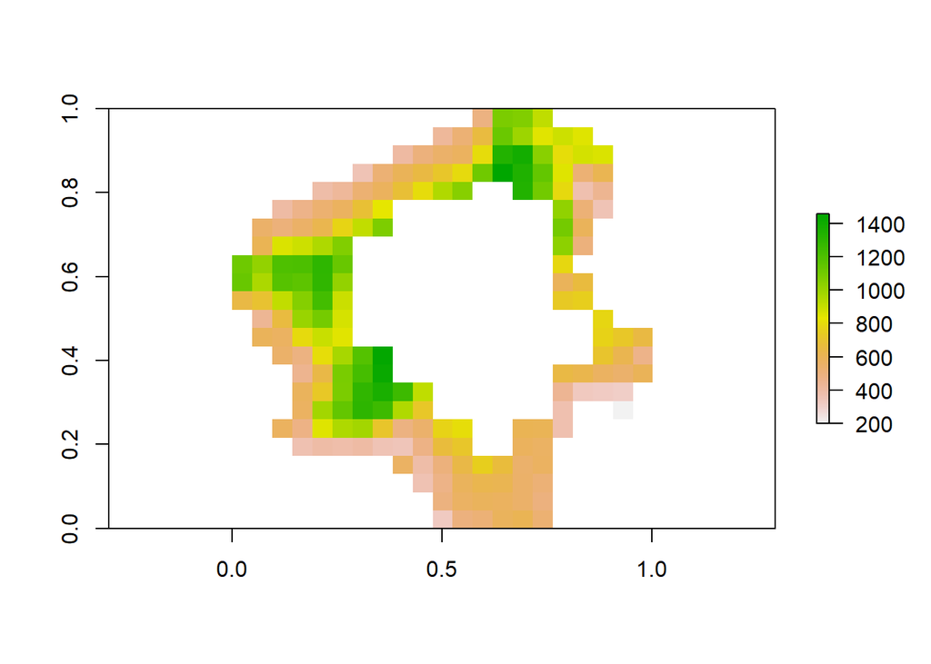

```r
result_clip = clip_sraster(result, mask = cluster_matrix, type ="Majority rule")
plot(funct_plot((result_clip$array)[,,1]))
```

## 2.3 Extracting spectral temporal information with ndvi rule

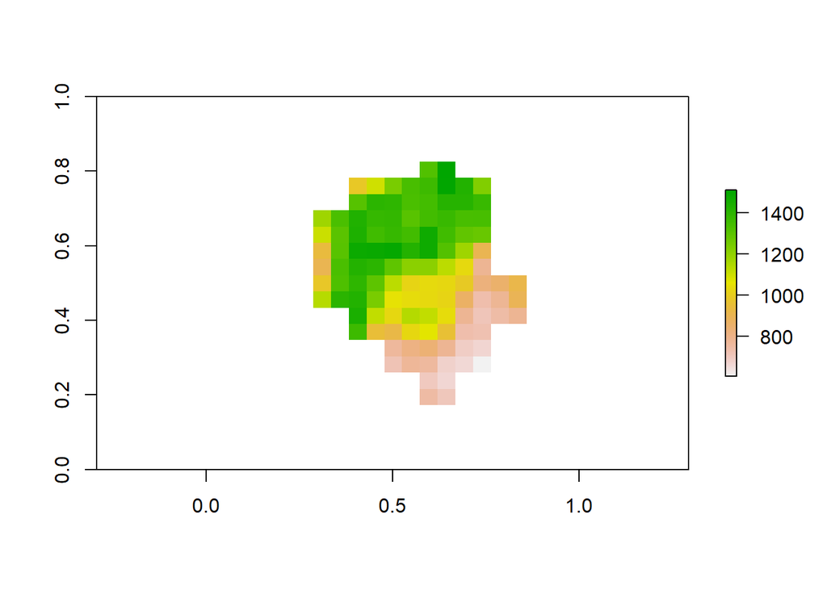

```r
result_clip = clip_sraster(result, mask = cluster_matrix, type ="rule_ndvi_water")
plot(funct_plot((result_clip$array)[,,1]))
```

# 3 Working with more polygons

Well, this workflow also attempts to construct a database with the spectral-temporal information that must be part of the trainig and validation modelling. So here we want to evaluate haw fast we can retrieve pseudotraining and put it a file that later on we will use for modelling.

This example covers only water. I want only call 20 polygons for this example

```r
#===============================
#random selection
#===============================
#Goal : stratified random selection of traing samples at level of polygon, (queriying only one class)

n_samples = 20
set.seed(123)   #setting same random selection for testing
index = sample(1:dim(legend_water)[1], n_samples,replace = FALSE)
query_water = legend_water[index,]
```

The following script contains the workflow that generalize the process done with the polygon of water done above. We require 3.5 seconds per polygon, so working with 20 this process can take one minute and 10 seconds more.

```r
list_shapes = split(query_water,query_water$OBJECTID)


workflow <- function(shape,paths_images){
          result = as_sraster(shape,paths_images)
          cluster_matrix = kmeans_sraster(result)
          result_clip = clip_sraster(result, mask = cluster_matrix, type ="rule_ndvi_water")
          return(as.data.frame(result_clip))
          }

result_list = lapply(list_shapes,workflow,paths_images)

result_df = do.call("rbind",result_list)
```

To save the results

```r
st_write(result_df, "output1.csv", layer_options = "GEOMETRY=AS_XY")
```